# Análisis de datos de Salarios del Dataset https://www.kaggle.com/datasets/ayeshasiddiqa123/salary-data

En este notebook se analizará el archivo `Salary_Data.csv`, que contiene información sobre salarios y años de experiencia.  
Utilizaremos las librerías **pandas** y **matplotlib** para realizar el análisis de manera estructurada y visual.

## 1. Importar e instalar las librerias correspondientes

```python
import pandas as pd
import matplotlib.pyplot as plt
```

## 2. Leer el archivo CSV

Usamos `pd.read_csv()` para cargar el archivo CSV en un DataFrame de pandas llamado `df`.  
El método `head()` nos muestra las primeras filas para revisar la estructura de los datos.

```python
df = pd.read_csv("Salary_Data.csv")
df.head()
```

|  | Age | Gender | Education Level | Job Title | Years of Experience | Salary |
| --- | --- | --- | --- | --- | --- | --- |
| 0 | 32.0 | Male | Bachelor's | Software Engineer | 5.0 | 90000.0 |
| 1 | 28.0 | Female | Master's | Data Analyst | 3.0 | 65000.0 |
| 2 | 45.0 | Male | PhD | Senior Manager | 15.0 | 150000.0 |
| 3 | 36.0 | Female | Bachelor's | Sales Associate | 7.0 | 60000.0 |
| 4 | 52.0 | Male | Master's | Director | 20.0 | 200000.0 |

## 3. Saber el volumen del dataframe

Podemos saber cuántas filas y columnas tiene nuestro df con los siguientes comandos:

```python
filas, columnas = df.shape
print(f"El archivo tiene {filas} filas y {columnas} columnas.")
```

```
El archivo tiene 6704 filas y 6 columnas.
```

```python
df.columns
```

```
Index(['Age', 'Gender', 'Education Level', 'Job Title', 'Years of Experience',
       'Salary'],
      dtype='object')
```

## 4. Saber la distribución de los datos

Con `df.describe()` obtenemos estadísticas descriptivas de las columnas numéricas:

- **count:** número de valores no nulos
- **mean:** media aritmética
- **std:** desviación estándar
- **min / max:** valores mínimo y máximo
- **25%, 50%, 75%:** percentiles

```python
df.describe()
```

|  | Age | Years of Experience | Salary |
| --- | --- | --- | --- |
| count | 6702.000000 | 6701.000000 | 6699.000000 |
| mean | 33.620859 | 8.094687 | 115326.964771 |
| std | 7.614633 | 6.059003 | 52786.183911 |
| min | 21.000000 | 0.000000 | 350.000000 |
| 25% | 28.000000 | 3.000000 | 70000.000000 |
| 50% | 32.000000 | 7.000000 | 115000.000000 |
| 75% | 38.000000 | 12.000000 | 160000.000000 |
| max | 62.000000 | 34.000000 | 250000.000000 |

### Primer análisis: 10 mejores salarios por puesto de trabajo

```python
df.groupby('Job Title')['Salary'].mean().sort_values(ascending=False).head(10)
```

```
Job Title
CEO                            250000.000000
Chief Technology Officer       250000.000000
Chief Data Officer             220000.000000
Director of Data Science       204561.403509
Director                       200000.000000
VP of Finance                  200000.000000
Operations Director            190000.000000
VP of Operations               190000.000000
Director of Human Resources    187500.000000
Marketing Director             183984.375000
Name: Salary, dtype: float64
```

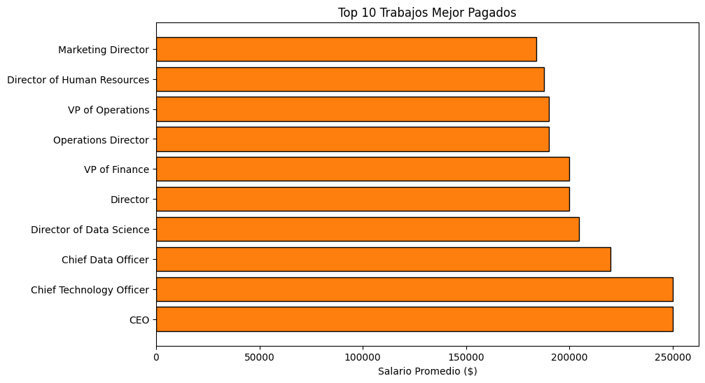

```python
top_jobs = df.groupby('Job Title')['Salary'].mean().sort_values(ascending=False).head(10)

plt.figure(figsize=(10,6))
plt.barh(top_jobs.index, top_jobs.values, color=['#ff7f0e'], edgecolor='black')
plt.xlabel("Salario Promedio ($)")
plt.title("Top 10 Trabajos Mejor Pagados")
plt.show()
```

### Segundo análisis: Tops 10 edades mejor pagadas

Agrupamos el DataFrame df con groupby por la columna Age (edad). Es decir, todas las personas que tienen la misma edad se agrupan juntas y se selecciona solo la columna Salary, se hacen un promedio del salario por edad y se ordena de mayor a menor los primeros 10.

```python
edades_mejor_pagadas= df.groupby('Age')['Salary'].mean().sort_values(ascending=False).head(10)
print(edades_mejor_pagadas)
```

```
Age
51.0    200356.066667
61.0    200000.000000
62.0    200000.000000
55.0    198482.187500
56.0    196577.636364
58.0    195715.428571
48.0    192723.846939
50.0    190849.897727
54.0    189816.250000
49.0    189013.582418
Name: Salary, dtype: float64
```

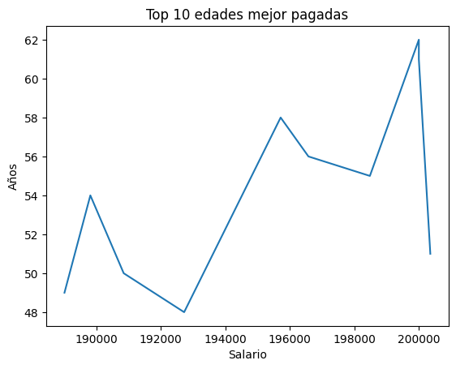

```python
plt.figure()
plt.plot(edades_mejor_pagadas.values, edades_mejor_pagadas.index)
plt.title("Top 10 edades mejor pagadas")
plt.xlabel("Salario")
plt.ylabel("Años")
plt.show()
```

### Tercer análisis: Comparación de salarios por género

resumen estadístico del salario por género con promedio, mediana y número de personas.

```python
salary_by_gender = df.groupby('Gender')['Salary'].agg(['mean', 'median', 'count'])
print(salary_by_gender )
```

```
                 mean    median  count
Gender
Female  107888.998672  105000.0   3013
Male    121389.870915  120000.0   3672
Other   125869.857143  158610.0     14
```

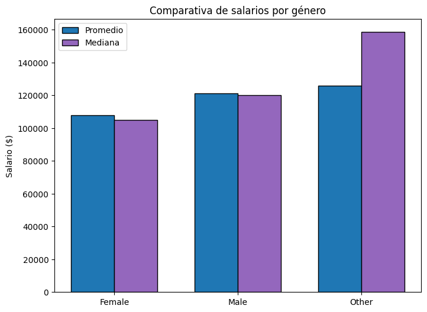

```python
fig, ax = plt.subplots(figsize=(8,6))
width = 0.35
x = range(len(salary_by_gender))

ax.bar(x, salary_by_gender['mean'], width=width, label='Promedio', color=['#1f77b4'], edgecolor='black')

ax.bar([i + width for i in x], salary_by_gender['median'], width=width, label='Mediana', color=['#9467bd'], edgecolor='black')

ax.set_xticks([i + width/2 for i in x])
ax.set_xticklabels(salary_by_gender.index)
ax.set_ylabel("Salario ($)")
ax.set_title("Comparativa de salarios por género")
ax.legend()
plt.show()
```

### Cuarto análisis: Salarios por rango de edad

(Para el cuarto, quito y sexto, usé ayuda de IA para experimentar con diferentes tipos de gráficas y vistas de datos. El prompt fue que me ayudara línea por línea explicándome como hacer un análisis básico con gráfica de cada estudio.)

Creamos los rangos de edades, calculamos su promedio por edades y cuántas personas hay en cada rango.

```python
edad_rangos = pd.cut(df['Age'],
                     bins=[20, 30, 40, 50, 65],
                     labels=['21-30 años', '31-40 años', '41-50 años', '51-62 años'])
salario_por_edad = df.groupby(edad_rangos, observed=True)['Salary'].mean().sort_index()

print("\nSalario promedio por rango de edad:")
print(salario_por_edad)

personas_por_edad = df.groupby(edad_rangos, observed=True).size()
print("\nCantidad de personas por rango:")
print(personas_por_edad)
```

```
Salario promedio por rango de edad:
Age
21-30 años     76611.118562
31-40 años    129199.120423
41-50 años    170070.030198
51-62 años    191834.751323
Name: Salary, dtype: float64

Cantidad de personas por rango:
Age
21-30 años    2894
31-40 años    2460
41-50 años    1159
51-62 años     189
dtype: int64
```

#### Creamos la gráfica

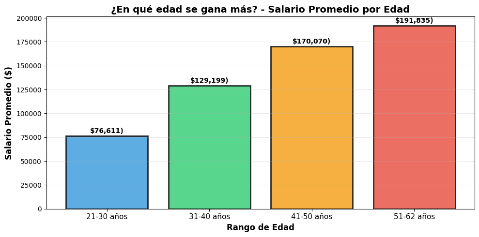

```
- En promedio, por cada 10 años de edad el salario aumenta: $38,408
```

```python
plt.figure(figsize=(10, 5))

colores = ['#3498db', '#2ecc71', '#f39c12', '#e74c3c']
barras = plt.bar(range(len(salario_por_edad)), salario_por_edad.values,
                 color=colores, edgecolor='black', linewidth=2, alpha=0.8)

plt.xlabel('Rango de Edad', fontsize=12, fontweight='bold')
plt.ylabel('Salario Promedio ($)', fontsize=12, fontweight='bold')
plt.title('¿En qué edad se gana más? - Salario Promedio por Edad', fontsize=14, fontweight='bold')
plt.xticks(range(len(salario_por_edad)), salario_por_edad.index, fontsize=11)
plt.grid(True, axis='y', alpha=0.3)

for i, (barra, valor) in enumerate(zip(barras, salario_por_edad.values)):
    plt.text(barra.get_x() + barra.get_width()/2, valor + 3000,
             f'${valor:,.0f})',
             ha='center', fontweight='bold', fontsize=10)

plt.tight_layout()
plt.show()

print(f"- En promedio, por cada 10 años de edad el salario aumenta: ${(salario_por_edad.max() - salario_por_edad.min())/3:,.0f}")
```

### Quinto análisis: Salario por nivel de educación

Resumen estadístico del salario por nivel de educación

```python
salary_by_education = df.groupby('Education Level')['Salary'].agg(['mean', 'median', 'count']).sort_values('mean', ascending=False)
print(salary_by_education)
```

```
                            mean    median  count
Education Level
PhD                165684.828947  170000.0   1368
Master's           157604.166667  177500.0    288
Master's Degree    125075.333969  122000.0   1572
Bachelor's         124767.658730  130000.0    756
phD                120000.000000  120000.0      1
Bachelor's Degree   85174.886093   75000.0   2265
High School         36706.694196   30000.0    448
```

### Creamos la gráfica

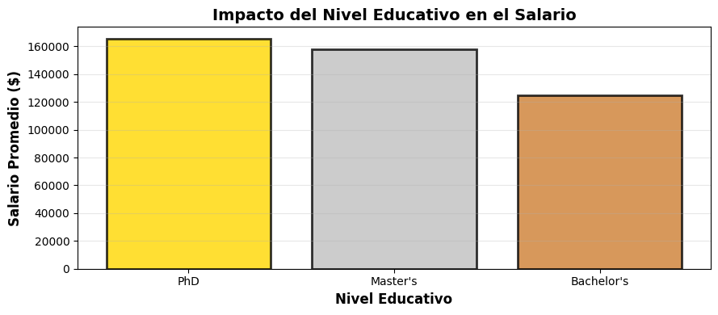

```python
plt.figure(figsize=(9, 4))

order = ["PhD", "Master's", "Bachelor's"]
education_data = []
for ed in order:
    if ed in salary_by_education.index:
        education_data.append(salary_by_education.loc[ed, 'mean'])

colors_edu = ['#FFD700', '#C0C0C0', '#CD7F32']
bars = plt.bar(order[:len(education_data)], education_data,
              color=colors_edu[:len(education_data)], alpha=0.8,
              edgecolor='black', linewidth=2)

plt.ylabel('Salario Promedio ($)', fontsize=12, fontweight='bold')
plt.xlabel('Nivel Educativo', fontsize=12, fontweight='bold')
plt.title('Impacto del Nivel Educativo en el Salario', fontsize=14, fontweight='bold')
plt.grid(True, axis='y', alpha=0.3)

plt.tight_layout()
plt.show()
```

### Sexto análisis: Salario por años de experiencia

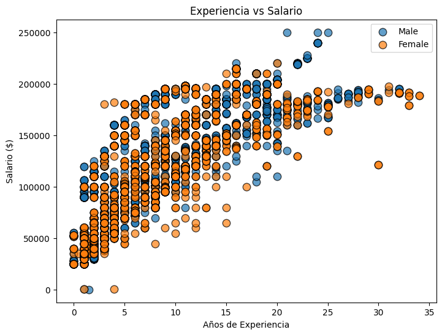

```python
plt.figure(figsize=(8,6))
for gender, color in zip(['Male','Female'], ['#3498db','#e74c3c']):
    subset = df[df['Gender']==gender]
    plt.scatter(subset['Years of Experience'], subset['Salary'], label=gender, s=80, alpha=0.7, edgecolor='black')

plt.xlabel("Años de Experiencia")
plt.ylabel("Salario ($)")
plt.title("Experiencia vs Salario")
plt.legend()
plt.show()
```